# Assignment 2

Suyeon Ryu

2020 9 22

```r
library(data.table)
library(dplyr)
library(dtplyr)
library(leaflet)
library(tidyverse)
setwd("C:/Users/suyeo/PM566/assignment2")
getwd()
```

```
## [1] "C:/Users/suyeo/PM566/assignment2"
```

```r
indiv <- read.csv("C:/Users/suyeo/PM566/assignment2/chs_individual.csv")
regional <- read.csv("C:/Users/suyeo/PM566/assignment2/chs_regional.csv")


head(indiv)
```

```
##   sid  townname male race hispanic    agepft height weight      bmi asthma
## 1   1 Lancaster    1    W        0 10.154689    123     54 16.22411      0
## 2   2 Lancaster    1    W        0 10.461328    145     77 16.64685      0
## 3   6 Lancaster    0    B        0 10.097194    145    143 30.91558      0
## 4   7 Lancaster    0    O        0 10.746064    156     72 13.44809      0
## 5   8 Lancaster    0    W        1  9.782341    132     61 15.91326      0
## 6  10 Lancaster    1    O        1        NA     NA     NA       NA      0
##   active_asthma father_asthma mother_asthma wheeze hayfever allergy
## 1             0             0             0      0        0       0
## 2             0             0             0      1        0       0
## 3             0             0             0      0        1       0
## 4             0            NA             0      1        0       0
## 5             0             1             0      1        1       1
## 6             1             1             0      0        0       0
##   educ_parent smoke pets gasstove      fev      fvc     mmef
## 1           3     0    1        1 1650.254 1800.005 2537.777
## 2           5     0    1        0 2273.129 2721.111 2365.745
## 3           2     0    0        1 2011.653 2257.244 1818.973
## 4           2     1    1        1 1643.092 2060.526 1462.500
## 5           3     0    1        0 1651.974 1996.382 1606.579
## 6           1     0    1        1       NA       NA       NA
```

```r
head(regional)
```

```
##        townname pm25_mass pm25_so4 pm25_no3 pm25_nh4 pm25_oc pm25_ec
## 1        Alpine      8.74     1.73     1.59     0.88    2.54    0.48
## 2 Lake Elsinore     12.35     1.90     2.98     1.36    3.64    0.62
## 3  Lake Gregory      7.66     1.07     2.07     0.91    2.46    0.40
## 4     Lancaster      8.50     0.91     1.87     0.78    4.43    0.55
## 5        Lompoc      5.96     1.08     0.73     0.41    1.45    0.13
## 6    Long Beach     19.12     3.23     6.22     2.57    5.21    1.36
##   pm25_om pm10_oc pm10_ec pm10_tc formic acetic  hcl hno3 o3_max o3106
## 1    3.04    3.25    0.49    3.75   1.03   2.49 0.41 1.98  65.82 55.05
## 2    4.36    4.66    0.63    5.29   1.18   3.56 0.46 2.63  66.70 54.42
## 3    2.96    3.16    0.41    3.57   0.66   2.36 0.28 2.28  84.44 67.01
## 4    5.32    5.68    0.56    8.61   0.88   2.88 0.22 1.80  54.81 43.88
## 5    1.74    1.86    0.14    1.99   0.34   0.75 0.33 0.43  43.85 37.74
## 6    6.25    6.68    1.39    8.07   1.57   2.94 0.73 2.67  39.44 28.22
##   o3_24   no2  pm10 no_24hr pm2_5_fr iacid oacid total_acids       lon
## 1 41.23 12.18 24.73    2.48    10.28  2.39  3.52        5.50 -116.7664
## 2 32.23 17.03 34.25    7.07    14.53  3.09  4.74        7.37 -117.3273
## 3 57.76  7.62 20.05      NA     9.01  2.56  3.02        5.30 -117.2752
## 4 32.86 15.77 25.04   12.68       NA  2.02  3.76        5.56 -118.1542
## 5 28.37  4.60 18.40    2.05       NA  0.76  1.09        1.52 -120.4579
## 6 18.22 33.11 38.41   36.76    22.23  3.40  4.51        7.18 -118.1937
##        lat
## 1 32.83505
## 2 33.66808
## 3 34.24290
## 4 34.68678
## 5 34.63915
## 6 33.77005
```

```r
chs <-(merge(x = indiv, y = regional, by.x="townname", by.y="townname", all.x=FALSE, all.y=FALSE))
```

# Part 1

## Question 1. check duplicates and match

```r
nrow(indiv)
```

```
## [1] 1200
```

```r
nrow(regional)
```

```
## [1] 12
```

```r
nrow(chs)
```

```
## [1] 1200
```

```r
head(chs)
```

```
##   townname sid male race hispanic    agepft height weight      bmi asthma
## 1   Alpine 841    1    W        1 10.548939    150     78 15.75758      0
## 2   Alpine 835    0    W        0 10.099932    143     69 15.33749      0
## 3   Alpine 838    0    O        1  9.486653    133     62 15.93183      0
## 4   Alpine 840    0    W        0  9.965777    146     78 16.63283      0
## 5   Alpine 865    0    W        0 10.039699    162    140 24.24797      1
## 6   Alpine 867    0    W        1  9.957563    141     94 21.49151      0
##   active_asthma father_asthma mother_asthma wheeze hayfever allergy
## 1             0             0             0      0        0       0
## 2             0             0             0      0        0       1
## 3             0             0             0      0        0       0
## 4             0             0             0      0        0       0
## 5             1             0             0      1        0       1
## 6             0            NA             0      0        0       0
##   educ_parent smoke pets gasstove      fev      fvc     mmef pm25_mass
```

[output cut: 27 more lines]

ANSWER : Indiv has row of 1200, regional dataset has row of 12. When merged, the chs data has 1200 rows, which makes sense.

## Question 2. Create a new var called “obesity_level”

```r
chs$obesity_level <- ifelse(chs$bmi > 24, "Obese",
                        ifelse(chs$bmi > 22, "Overweight",
                          ifelse(chs$bmi>14, "Normal", "Underweight")))

head(chs)
```

```
##   townname sid male race hispanic    agepft height weight      bmi asthma
## 1   Alpine 841    1    W        1 10.548939    150     78 15.75758      0
## 2   Alpine 835    0    W        0 10.099932    143     69 15.33749      0
## 3   Alpine 838    0    O        1  9.486653    133     62 15.93183      0
## 4   Alpine 840    0    W        0  9.965777    146     78 16.63283      0
## 5   Alpine 865    0    W        0 10.039699    162    140 24.24797      1
## 6   Alpine 867    0    W        1  9.957563    141     94 21.49151      0
##   active_asthma father_asthma mother_asthma wheeze hayfever allergy
## 1             0             0             0      0        0       0
## 2             0             0             0      0        0       1
## 3             0             0             0      0        0       0
## 4             0             0             0      0        0       0
## 5             1             0             0      1        0       1
## 6             0            NA             0      0        0       0
##   educ_parent smoke pets gasstove      fev      fvc     mmef pm25_mass
```

[output cut: 27 more lines]

```r
by_cat <- group_by(chs,obesity_level)
summarise(by_cat,
          bmi_min = min(bmi, by=obesity_level, na.rm=TRUE),
          bmi_max = max(bmi, na.rm=TRUE),
          count = n())
```

```
## # A tibble: 5 x 4
##   obesity_level bmi_min  bmi_max count
##   <chr>         <chr>      <dbl> <int>
## 1 Normal        14.0038     22.0   886
## 2 Obese         24.00647    41.3   103
## 3 Overweight    22.02353    24.0    87
## 4 Underweight   11.2964     14.0    35
## 5 <NA>          <NA>      -Inf      89
```

ANSWER : I can confirm from the summary table that the variable obesity_level is codded appropriately.

## Question 3. Create a var called “smoke_gas_exposure”

```r
chs$smoke_gas_exposure <- ifelse(chs$smoke == 0 & chs$gasstove == 0, "No Exposure",
        ifelse(chs$smoke == 1 & chs$gasstove == 0, "2nd hand Smoke Exposure",
               ifelse(chs$smoke == 0 & chs$gasstove == 1, "Gas Stove Exposure", "Double Exposure")))

tail(chs)
```

```
##      townname  sid male race hispanic    agepft height weight      bmi
## 1195   Upland 1866    0    O        1  9.806982    139     60 14.11559
## 1196   Upland 1867    0    M        1  9.618070    140     71 16.46568
## 1197   Upland 2033    0    M        0 10.121834    130     67 18.02044
## 1198   Upland 2031    1    W        0  9.798768    135     83 20.70084
## 1199   Upland 2032    1    W        0  9.549624    137     59 14.28855
## 1200   Upland 2053    0    W        0        NA     NA     NA       NA
##      asthma active_asthma father_asthma mother_asthma wheeze hayfever
## 1195      0             0            NA             0      0       NA
## 1196      0             0             1             0      0        0
## 1197      0             1             0             0      1        1
## 1198      0             0             0             0      1        0
## 1199      0             0             0             1      1        1
## 1200      0             0             0             0      0        0
##      allergy educ_parent smoke pets gasstove      fev      fvc     mmef
```

[output cut: 34 more lines]

ANSWER : The new smoke_gas_exposure variable is made. The 4 categories made are : No exposure, gas stove exposure, 2nd hand smoke exposure, and double exposure.

## Question 4. Create four summary tables

```r
chs2 <- chs
fev_asthma <- select(chs2, townname, male, obesity_level, smoke_gas_exposure, fev, asthma)
head(fev_asthma)
```

```
##   townname male obesity_level smoke_gas_exposure      fev asthma
## 1   Alpine    1        Normal        No Exposure 2251.505      0
## 2   Alpine    0        Normal        No Exposure 2529.276      0
## 3   Alpine    0        Normal               <NA> 1737.793      0
## 4   Alpine    0        Normal               <NA> 2466.791      0
## 5   Alpine    0         Obese Gas Stove Exposure 2583.934      1
## 6   Alpine    0        Normal Gas Stove Exposure 1973.115      0
```

```r
## by town
by_town <- group_by(chs2, townname)
a<-summarize(by_town,
          avg_fev = mean(fev, na.rm=TRUE),
          sd_fev = sd(fev, na.rm=TRUE))
prop_asthma <- table(chs2$asthma, by = chs2$townname)
prop_asthma <- prop.table(prop_asthma)

town_sum <-(merge(x = a , y = prop_asthma, by.x="townname", by.y="by", all.x=FALSE, all.y=FALSE))
town_sum
```

```
##         townname  avg_fev   sd_fev Var1        Freq
## 1         Alpine 2089.014 298.2039    0 0.073567151
## 2         Alpine 2089.014 298.2039    1 0.009409752
## 3     Atascadero 2079.374 331.8782    0 0.062446536
## 4     Atascadero 2079.374 331.8782    1 0.021385800
## 5  Lake Elsinore 2039.787 317.6112    0 0.071000855
## 6  Lake Elsinore 2039.787 317.6112    1 0.010265184
## 7   Lake Gregory 2091.665 337.8286    0 0.071856287
## 8   Lake Gregory 2091.665 337.8286    1 0.012831480
## 9      Lancaster 2002.550 337.1053    0 0.069289991
## 10     Lancaster 2002.550 337.1053    1 0.013686912
## 11        Lompoc 2038.227 367.4474    0 0.073567151
## 12        Lompoc 2038.227 367.4474    1 0.009409752
## 13    Long Beach 1983.896 330.6271    0 0.071000855
## 14    Long Beach 1983.896 330.6271    1 0.011120616
## 15     Mira Loma 1984.726 336.6416    0 0.068434559
## 16     Mira Loma 1984.726 336.6416    1 0.012831480
## 17     Riverside 1986.212 289.7415    0 0.076133447
## 18     Riverside 1986.212 289.7415    1 0.009409752
## 19     San Dimas 2027.806 321.9740    0 0.070145423
## 20     San Dimas 2027.806 321.9740    1 0.014542344
## 21   Santa Maria 2022.553 330.0457    0 0.071856287
## 22   Santa Maria 2022.553 330.0457    1 0.011120616
## 23        Upland 2027.284 357.2010    0 0.074422583
## 24        Upland 2027.284 357.2010    1 0.010265184
```

```r
## by sex
by_sex <- group_by(chs2, male)
b<-summarize(by_sex,
          avg_fev = mean(fev, na.rm=TRUE),
          sd_fev = sd(fev, na.rm=TRUE))
b_table <- table(chs2$asthma, by = chs2$male)
b_table <- prop.table(b_table)

sex_sum <-(merge(x = b , y = b_table, by.x="male", by.y="by", all.x=FALSE, all.y=FALSE))
sex_sum
```

```
##   male  avg_fev   sd_fev Var1       Freq
## 1    0 1959.105 327.2948    0 0.44824636
## 2    0 1959.105 327.2948    1 0.06159110
## 3    1 2103.819 318.2036    0 0.40547476
## 4    1 2103.819 318.2036    1 0.08468777
```

```r
## by obesity level
by_obesity <- group_by(chs2, obesity_level)
c <- summarize(by_obesity,
          avg_fev = mean(fev, na.rm=TRUE),
          sd_fev = sd(fev, na.rm=TRUE))
c_table <- table(chs2$asthma, by = chs2$obesity_level)
c_table <- prop.table(c_table)


obesity_sum <-(merge(x = c , y = c_table, by.x="obesity_level", by.y="by", all.x=FALSE, all.y=FALSE))
obesity_sum
```

```
##   obesity_level  avg_fev   sd_fev Var1        Freq
## 1        Normal 1997.974 309.4085    0 0.684792627
## 2        Normal 1997.974 309.4085    1 0.112442396
## 3         Obese 2269.295 325.5054    0 0.072811060
## 4         Obese 2269.295 325.5054    1 0.019354839
## 5    Overweight 2224.322 317.4261    0 0.065437788
## 6    Overweight 2224.322 317.4261    1 0.012903226
## 7   Underweight 1686.800 300.0803    0 0.029493088
## 8   Underweight 1686.800 300.0803    1 0.002764977
```

```r
## by smoke_gas_exposure
by_sge <- group_by(chs2, smoke_gas_exposure)
d <- summarise(by_sge,
          avg_fev = mean(fev, na.rm=TRUE),
          sd_fev = sd(fev, na.rm=TRUE))
d_table <- table(chs2$asthma, by = chs2$smoke_gas_exposure)
d_table <- prop.table(d_table)

sge_sum <-(merge(x = d , y = d_table, by.x="smoke_gas_exposure", by.y="by", all.x=FALSE, all.y=FALSE))
sge_sum
```

```
##        smoke_gas_exposure  avg_fev   sd_fev Var1        Freq
## 1 2nd hand Smoke Exposure 2064.346 333.2266    0 0.025846702
## 2 2nd hand Smoke Exposure 2064.346 333.2266    1 0.005347594
## 3         Double Exposure 2019.974 313.2327    0 0.113190731
## 4         Double Exposure 2019.974 313.2327    1 0.016934046
## 5      Gas Stove Exposure 2026.308 328.1240    0 0.555258467
## 6      Gas Stove Exposure 2026.308 328.1240    1 0.096256684
## 7             No Exposure 2059.943 342.5625    0 0.159536542
## 8             No Exposure 2059.943 342.5625    1 0.027629234
```

ANSWER:

BY OBESITY LEVEL - The highest level of average forced expiratory volume was observed from obese BMI people, and it decreased respectively with BMI level. - The highest level of asthma was observed from normal BMI people. The lowest was observed from underweight people(less than 1 percent).

BY SMOKE GAS EXPOSURE LEVEL - The highest level of average forced expiratory volume was observd from people with the second hand smoke exposures. The lowest FEV was observed from double exposure people. - The highest level of asthma was observed from people with gas stove exposure, which take up 9.6 percent.

# Part 2

## check dimensions/ take a closer look at var

```r
one <- select(chs2,townname, bmi, fev, obesity_level, smoke_gas_exposure, pm25_mass, lat, lon)

dim(one)
```

```
## [1] 1200    8
```

```r
nrow(one)
```

```
## [1] 1200
```

```r
ncol(one)
```

```
## [1] 8
```

```r
head(one)
```

```
##   townname      bmi      fev obesity_level smoke_gas_exposure pm25_mass
## 1   Alpine 15.75758 2251.505        Normal        No Exposure      8.74
## 2   Alpine 15.33749 2529.276        Normal        No Exposure      8.74
## 3   Alpine 15.93183 1737.793        Normal               <NA>      8.74
## 4   Alpine 16.63283 2466.791        Normal               <NA>      8.74
## 5   Alpine 24.24797 2583.934         Obese Gas Stove Exposure      8.74
## 6   Alpine 21.49151 1973.115        Normal Gas Stove Exposure      8.74
##        lat       lon
## 1 32.83505 -116.7664
## 2 32.83505 -116.7664
## 3 32.83505 -116.7664
## 4 32.83505 -116.7664
## 5 32.83505 -116.7664
## 6 32.83505 -116.7664
```

```r
tail(one)
```

```
##      townname      bmi      fev obesity_level smoke_gas_exposure pm25_mass
## 1195   Upland 14.11559 1691.275        Normal        No Exposure     22.46
## 1196   Upland 16.46568 1733.338        Normal        No Exposure     22.46
## 1197   Upland 18.02044 1929.866        Normal Gas Stove Exposure     22.46
## 1198   Upland 20.70084 2034.177        Normal Gas Stove Exposure     22.46
## 1199   Upland 14.28855 2077.703        Normal Gas Stove Exposure     22.46
## 1200   Upland       NA       NA          <NA>        No Exposure     22.46
##           lat       lon
## 1195 34.09751 -117.6484
## 1196 34.09751 -117.6484
## 1197 34.09751 -117.6484
## 1198 34.09751 -117.6484
## 1199 34.09751 -117.6484
## 1200 34.09751 -117.6484
```

```r
str(one)
```

```
## 'data.frame':    1200 obs. of  8 variables:
##  $ townname          : Factor w/ 12 levels "Alpine","Atascadero",..: 1 1 1 1 1 1 1 1 1 1 ...
##  $ bmi               : num  15.8 15.3 15.9 16.6 24.2 ...
##  $ fev               : num  2252 2529 1738 2467 2584 ...
##  $ obesity_level     : chr  "Normal" "Normal" "Normal" "Normal" ...
##  $ smoke_gas_exposure: chr  "No Exposure" "No Exposure" NA NA ...
##  $ pm25_mass         : num  8.74 8.74 8.74 8.74 8.74 8.74 8.74 8.74 8.74 8.74 ...
##  $ lat               : num  32.8 32.8 32.8 32.8 32.8 ...
##  $ lon               : num  -117 -117 -117 -117 -117 ...
```

```r
summary(one)
```

```
##           townname        bmi             fev         obesity_level
##  Alpine       :100   Min.   :11.30   Min.   : 984.8   Length:1200
##  Atascadero   :100   1st Qu.:15.78   1st Qu.:1809.0   Class :character
##  Lake Elsinore:100   Median :17.48   Median :2022.7   Mode  :character
##  Lake Gregory :100   Mean   :18.50   Mean   :2031.3
##  Lancaster    :100   3rd Qu.:20.35   3rd Qu.:2249.7
##  Lompoc       :100   Max.   :41.27   Max.   :3323.7
##  (Other)      :600   NA's   :89      NA's   :95
##  smoke_gas_exposure   pm25_mass           lat             lon
##  Length:1200        Min.   : 5.960   Min.   :32.84   Min.   :-120.7
##  Class :character   1st Qu.: 7.615   1st Qu.:33.93   1st Qu.:-118.8
##  Mode  :character   Median :10.545   Median :34.10   Median :-117.7
##                     Mean   :14.362   Mean   :34.20   Mean   :-118.3
##                     3rd Qu.:20.988   3rd Qu.:34.65   3rd Qu.:-117.4
##                     Max.   :29.970   Max.   :35.49   Max.   :-116.8
##
```

## Validate against external source

all BMI, fev, pm25_mass are within expected ranges compared to external sources

## 2.1 facet plot bmi vs fev, by townname

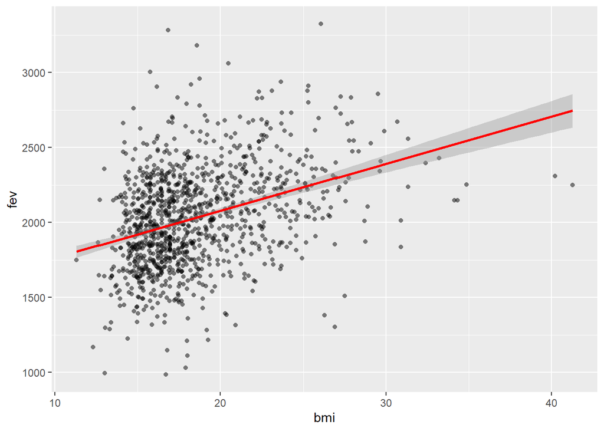

```r
library(ggplot2)

bmi_fev = ggplot(one, aes(x=bmi, y=fev)) +
  geom_point(shape=16,
             color = 'black',
             alpha = 0.5) +
  geom_smooth(method=lm, color = 'red')
bmi_fev
```

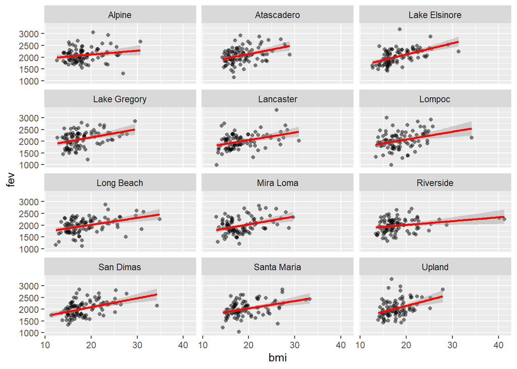

```r
bmi_fev + facet_wrap(~townname, ncol=3)
```

ANSWER : for each and every tonw, the increased bmi is directly related in increased forced expiratory volumes based on the plots.

## 2.2 stacked histograms

Stacked histogram of FEV by BMI category

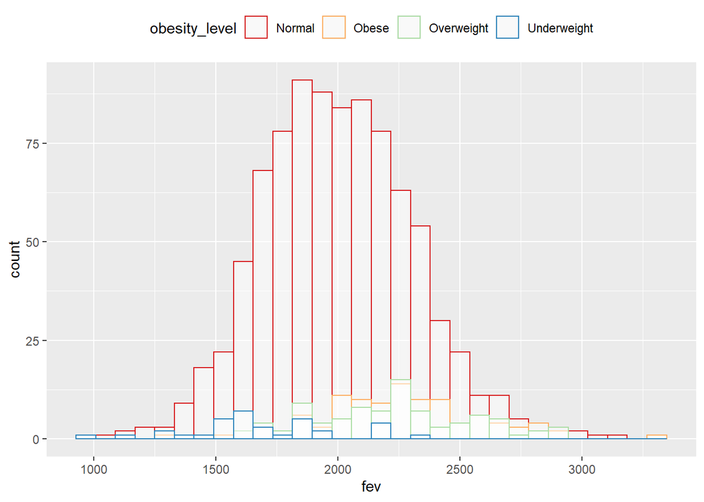

```r
z<-ggplot(one, aes(x=fev, color=obesity_level)) +
  geom_histogram(fill="white", alpha=0.5, position="identity") +
  theme(legend.position="top")

z+scale_color_brewer(palette = "Spectral")
```

ANSWER : each categories are pretty normally distributed. The FEV for underweight shows the lowest fev counts throughout. In terms of ranges, normal, overweight, and obese do not show significant differences.

Stacked histogram of FEV by smoke/gas exposure

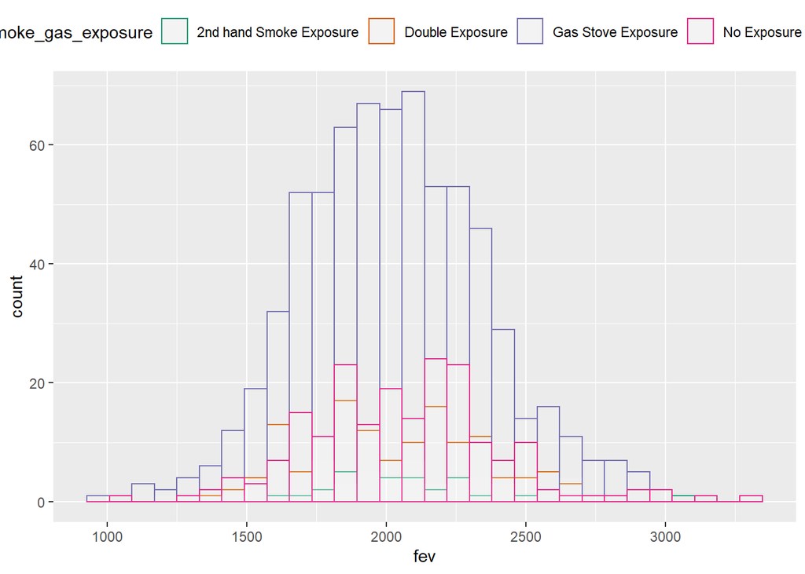

```r
x<-ggplot(one, aes(x=fev, color=smoke_gas_exposure)) +
  geom_histogram(fill="white", alpha=0.1, position="identity") +
  theme(legend.position="top")

x+scale_color_brewer(palette = "Dark2")
```

ANSWER : each categories of the smoke_gas_exposure show pretty similar median for each category. From the stacked histogram, it is hard to say that the fev patterns are different from each other.

## 2.3 barchart of BMi by smoke/gas exposure

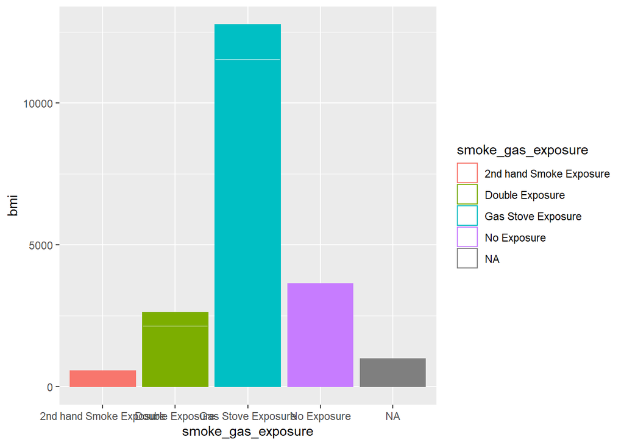

```r
y<-ggplot(one, aes(x=smoke_gas_exposure, y=bmi, color=smoke_gas_exposure)) +
   geom_bar(stat="identity", fill="white")
y
```

## 2.4 Statistical summary graphs of FEV by bmi and FEV by smoke/gas exposure cateogry

Summary graph of FEV by BMI

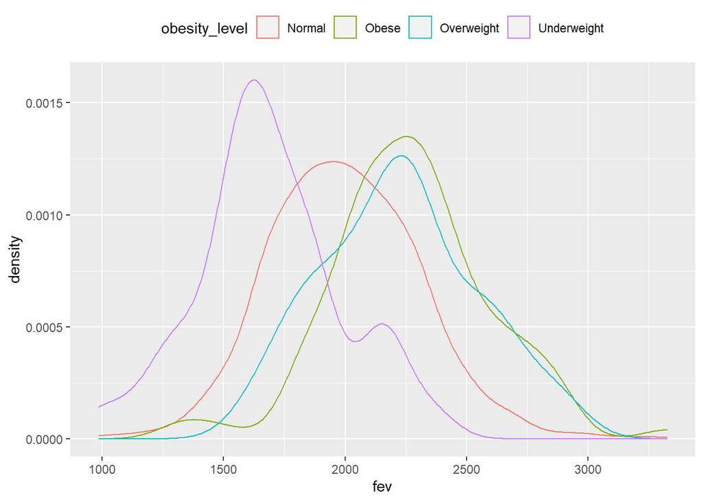

```r
ggplot(one, aes(fev, fill = bmi, colour = obesity_level)) +
  geom_density(alpha = 0.5, na.rm = TRUE) +
  theme(legend.position = "none")+
  theme(legend.position="top")
```

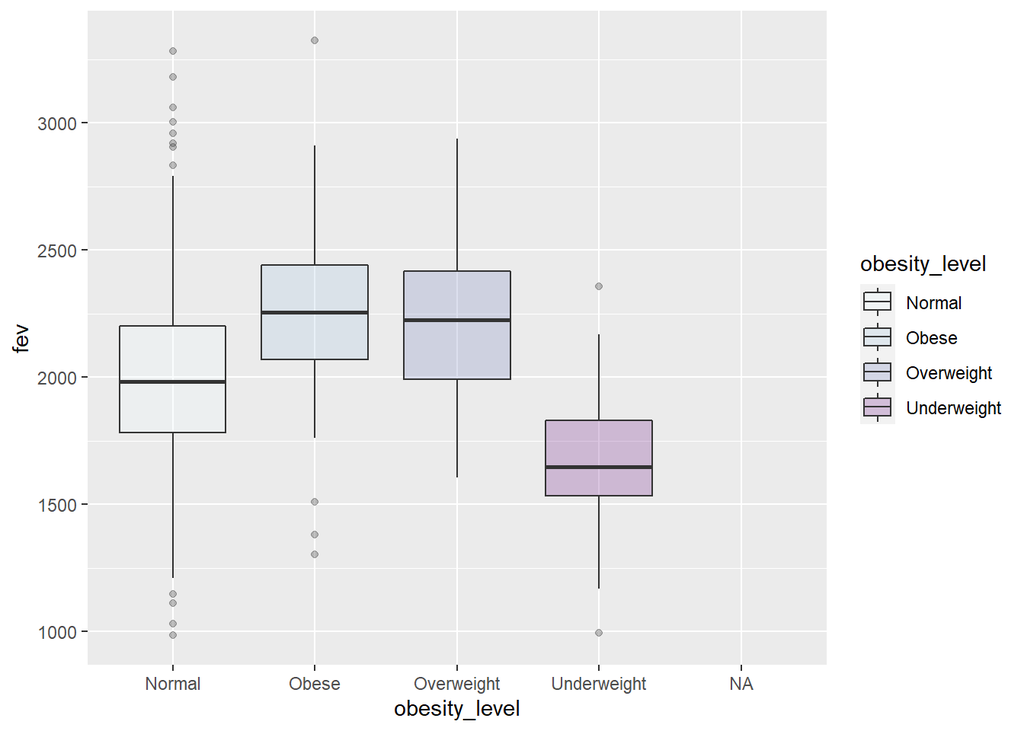

```r
s<- one %>%
  ggplot+
  aes(x = obesity_level, y = fev, fill = obesity_level)+
  geom_boxplot(alpha=0.3)+
  scale_fill_brewer(palette="BuPu")


s
```

ANSWER: From the summary statistics, it looks like the underweight people show the lowest FEV levels, and the obese people show the highest FEV level, although it is closely followed by Overweight subjects.

Summary graph of FEV by smoke/gas exposure category

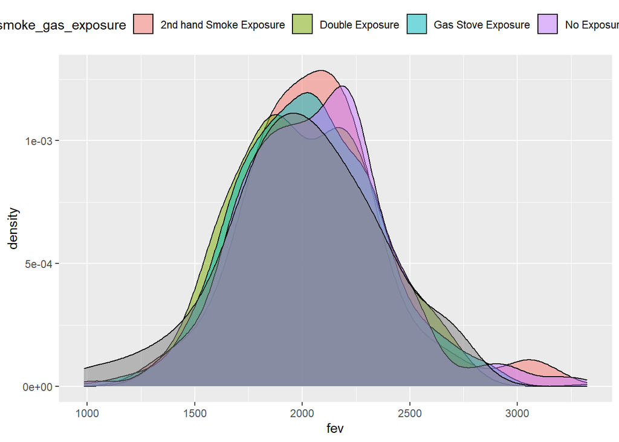

```r
ggplot(one, aes(fev, fill = smoke_gas_exposure)) +
  geom_density(alpha = 0.5, na.rm = TRUE) +
  theme(legend.position = "none")+
  theme(legend.position="top")
```

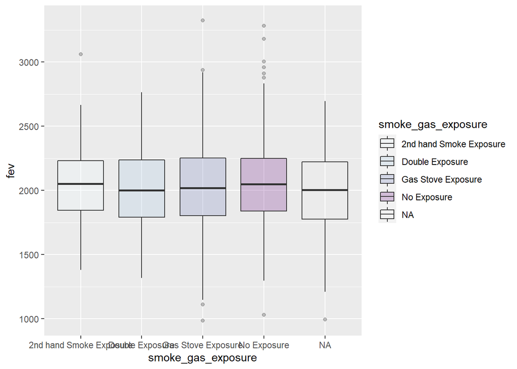

```r
t<- one %>%
  ggplot+
  aes(x = smoke_gas_exposure, y = fev, fill = smoke_gas_exposure)+
  geom_boxplot(alpha=0.3)+
  scale_fill_brewer(palette="BuPu")


t
```

ANSWER : From the summary graph of FEV by smoke/gas exposure categories, there are no significance differences between FEV level and smoke/gas exposure levels.

## 2.5 Leaflet map of concentration of PM2.5 mass

```r
location <- (unique(one[,c("lat","lon")]))
dim(location)
```

```
## [1] 12  2
```

```r
library(leaflet)
leaflet(location) %>%
  addProviderTiles('CartoDB.Positron') %>%
  addCircles(lat=~lat,lng=~lon, opacity=1, fillOpacity=1, radius=400, weight = 20, color = "purple")
```

[interactive chart not shown]

ANSWER : There are 12 unique locations where PM2.5 mass are concentrated and measured from.

## 2.6 Visualization of association between PM2.5mass versus FEV

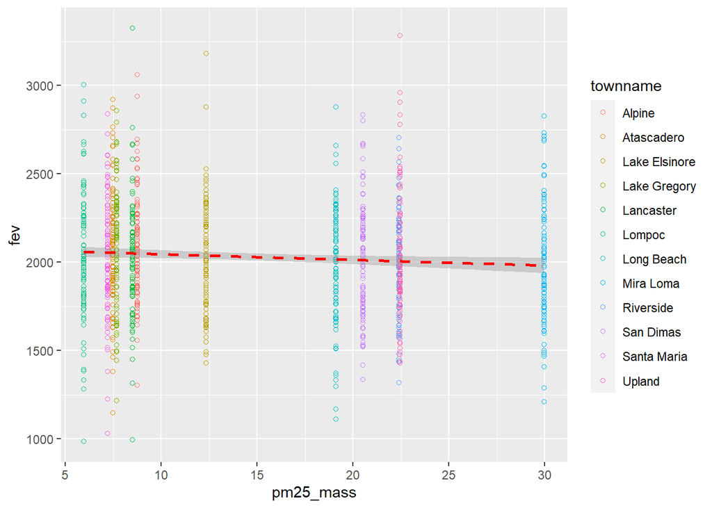

```r
ggplot(one, aes(x=pm25_mass, y=fev, color=townname)) +
    geom_point(shape=1) +    # Use hollow circles
    geom_smooth(method = lm, linetype = "dashed", color = "red")
```

ANSWER: It does not look like it has significant effect between pm25_mass with forced expiratory volume.